# HW4

Two trade-offs: I. Interpretability. BoW has a high interpretability, In a Document-Term Matrix, every feature (column) is a literal word. If a model predicts that a text is "conservative," a social scientist can point directly to words like "tradition" or "market" as the cause. While embeddings capture "hidden" meanings, they are non-interpretable. It's hard to justify "why" a model reached a specific conclusion in a peer-reviewed paper.

II. Data Sparsity vs. Computational Robustness BoW (Sparsity Issues): BoW suffers from the "curse of dimensionality." If two people use different synonyms to describe the same social phenomenon, BoW treats them as entirely unrelated, potentially missing patterns in small datasets. While embeddings project words into a shared space, making the model robust to variations in vocabulary. However, modern transformers require significant computational power and large corpora to perform well.

Concrete Examples in Social Science Example of using bag-of-words: Tracking the specific mention of "Carbon Tax" vs. "Green Energy" across party platforms over 20 years. It's used when we need to count specific tokens to show how rhetoric shifts. The transparency of BoW allows for clear frequency-based evidence that is easy to validate and communicate to stakeholders. When to prefer Embeddings: Measuring Implicit Cultural Bias. For instance, analyzing historical newspapers to see how the "closeness" of two terms has changed over a century. This research relies on latent associations rather than word counts.

```
--- Document-term matrix (counts) ---
Shape: (800, 4012)
Vocabulary size: 4012
Example vocab terms: ['abandon' 'abandoned' 'abandoning' 'abandons' 'abducted' 'ability' 'able'
 'aboard' 'abruptly' 'absence' 'absolutely' 'abuse' 'abusive' 'academic'
 'academy' 'accept' 'acceptance' 'accepted' 'accepting' 'accepts']

--- LDA topics: top words ---

Topic 0:
  michael         147.74
  film            141.16
  father          125.72
  time            109.12
  house           106.21
  family          97.18
  life            93.99
  john            93.19
  mother          84.91
  home            82.13

Topic 1:
  love            192.17
  father          164.84
  life            146.80
  film            142.71
  family          109.81
  man             109.64
  tells           108.96
  girl            98.36
  son             97.17
  people          94.65

Topic 2:
  police          168.28
  paul            142.46
  new             97.55
  time            92.39
  goes            89.02
  day             85.58
```

[output cut: 48 more lines]

```
  jerry           48.01
  john            45.13
  eric            44.31
  mouse           43.01

--- LDA: dominant topic counts ---
lda_topic
0    186
1    198
2    130
3    118
4     85
5     40
6     43
Name: count, dtype: int64
```

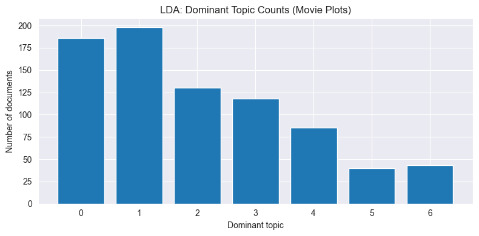

```python
import os
import re
import random
import tarfile
import ast
import numpy as np
import pandas as pd
import matplotlib.pyplot as plt
from sklearn.feature_extraction.text import CountVectorizer
from sklearn.decomposition import LatentDirichletAllocation
from sklearn.model_selection import train_test_split
from sklearn.linear_model import Ridge
from sklearn.metrics import mean_absolute_error, mean_squared_error, r2_score
import ast
from gensim.models import Word2Vec
from sentence_transformers import SentenceTransformer
from bertopic import BERTopic
from umap import UMAP
import hdbscan
from wordcloud import WordCloud
import pyLDAvis
import pyLDAvis.lda_model
import seaborn as sns
from sklearn.manifold import TSNE

# Reproducibility
random.seed(123)
np.random.seed(123)

# Create project folders (safe to run repeatedly)
os.makedirs("/Users/a75700/Desktop/soda_501/soda_501/04_text_as_data", exist_ok=True)
os.makedirs("/Users/a75700/Desktop/soda_501/soda_501/04_text_as_data/data_processed", exist_ok=True)
os.makedirs("/Users/a75700/Desktop/soda_501/soda_501/04_text_as_data/figures", exist_ok=True)
os.makedirs("/Users/a75700/Desktop/soda_501/soda_501/04_text_as_data/outputs", exist_ok=True)
os.makedirs("/Users/a75700/Desktop/soda_501/soda_501/04_text_as_data/src", exist_ok=True)

# load the df
df = pd.read_csv("/Users/a75700/Desktop/soda_501/soda_501/04_text_as_data/week_movie_corpus.csv")

# tokenization
vectorizer = CountVectorizer(
    lowercase=True, #
    stop_words="english",
    token_pattern=r"(?u)\b[a-zA-Z][a-zA-Z]+\b",  # words with >=2 letters
    min_df=5 # words that show up in at least 5 documents
)

X_counts = vectorizer.fit_transform(df["text"])
vocab = vectorizer.get_feature_names_out() # extract vocabs

print("\n--- Document-term matrix (counts) ---")
print("Shape:", X_counts.shape)  # (n_docs, n_terms)
print("Vocabulary size:", len(vocab))
print("Example vocab terms:", vocab[:20]) # 20 word lists

# LDA with 7 topics
n_topics = 7
lda = LatentDirichletAllocation(
    n_components=n_topics,
    random_state=123,
    learning_method="batch"
)
lda.fit(X_counts)

# Topic-word distributions
topic_word = lda.components_  # shape: (K, n_terms)

#top 10 words for each topic
print("\n--- LDA topics: top words ---")
n_top_words = 10
for k in range(n_topics):
    top_word_idx = topic_word[k].argsort()[::-1][:n_top_words]
    # topic_word[k]: vector of the weights of all words in k topic
    # .argsort: index in sequential order
    # [::-1] reverse the order: from large to small
    # [:n_top_words] only take the 10 words
    words = vocab[top_word_idx]
    weights = topic_word[k][top_word_idx]
    print(f"\nTopic {k}:")
    for w, wt in zip(words, weights):
        print(f"  {w:15s} {wt:,.2f}")

# number of document per topic
doc_topic = lda.transform(X_counts)  # shape: (n_docs, K)
df_lda = df.copy()
df_lda["lda_topic"] = doc_topic.argmax(axis=1) # find the maximum likelihood
df_lda["lda_topic_prob"] = doc_topic.max(axis=1) # topic probability

print("\n--- LDA: dominant topic counts ---")
print(df_lda["lda_topic"].value_counts().sort_index())

df_lda.to_csv("/Users/a75700/Desktop/soda_501/soda_501/04_text_as_data/data_processed/week_with_lda_topics.csv", index=False)

topic_counts = df_lda["lda_topic"].value_counts().sort_index()
plt.figure(figsize=(8, 4))
plt.bar(topic_counts.index.astype(str), topic_counts.values)
plt.title("LDA: Dominant Topic Counts (Movie Plots)")
plt.xlabel("Dominant topic")
plt.ylabel("Number of documents")
plt.tight_layout()
plt.savefig("/Users/a75700/Desktop/soda_501/soda_501/04_text_as_data/data_processed/week_lda_dominant_topic_counts.png", dpi=200)
plt.show()
plt.close()
```

```python
I choose topic 0 and 1 to interprete. Topic 0 and 1 share a common narrative vacabulary with most vocabularies related to family topic. The overlap in terms like father and family reflects the prevalence of family-related language across the corpus and illustrates how preprocessing choices affect topic distinctiveness. In particular, removing high-frequency but low-discriminative words such as film or life could improve separation between topics.
```

[output not shown]

```
--- Transformer embedding matrix ---
Shape: (800, 384)
```

```
2026-02-08 22:03:22,398 - BERTopic - Dimensionality - Completed ✓
2026-02-08 22:03:22,400 - BERTopic - Cluster - Start clustering the reduced embeddings
2026-02-08 22:03:22,433 - BERTopic - Cluster - Completed ✓
2026-02-08 22:03:22,439 - BERTopic - Representation - Fine-tuning topics using representation models.
2026-02-08 22:03:22,533 - BERTopic - Representation - Completed ✓
```

```
--- BERTopic: topic counts ---
-1     306
 0      77
 1      73
 2      45
 3      39
 4      29
 5      25
 6      25
 7      22
 8      21
 9      20
 10     18
 11     17
 12     16
```

[output cut: 46 more lines]

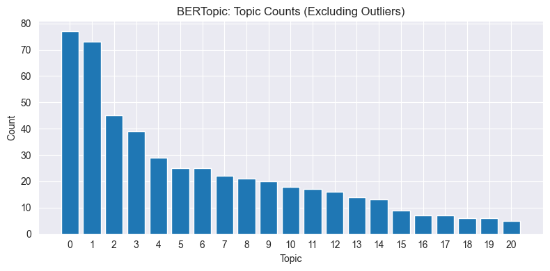

```python
# Bert topic
embed_model = SentenceTransformer("all-MiniLM-L6-v2") # load embedding model
embeddings = embed_model.encode(df["text"].tolist(), show_progress_bar=True)
# transform into vectors
print("\n--- Transformer embedding matrix ---")
print("Shape:", embeddings.shape)

umap_model = UMAP(
    n_neighbors=15,
    n_components=5,
    min_dist=0.0,
    metric="cosine",
    random_state=123
)

hdbscan_model = hdbscan.HDBSCAN(
    min_cluster_size=5,
    metric="euclidean",
    cluster_selection_method="eom",
    prediction_data=True
)

topic_model = BERTopic(
    umap_model=umap_model,
    hdbscan_model=hdbscan_model,
    calculate_probabilities=True,
    verbose=True
)

topics, probs = topic_model.fit_transform(df["text"].tolist(), embeddings)

df_bert = df.copy()
df_bert["bertopic_topic"] = topics
df_bert["bertopic_max_prob"] = np.max(probs, axis=1)

print("\n--- BERTopic: topic counts ---")
print(pd.Series(topics).value_counts().sort_index())

topic_info = topic_model.get_topic_info()
print("\n--- BERTopic: topic info (head) ---")
print(topic_info.head(10))

df_bert.to_csv("/Users/a75700/Desktop/soda_501/soda_501/data_processed/week_with_bertopic.csv", index=False)
topic_info.to_csv("/Users/a75700/Desktop/soda_501/soda_501/outputs/week_bertopic_topic_info.csv", index=False)

topic_counts_bt = topic_info.loc[topic_info["Topic"] != -1, ["Topic", "Count"]]
plt.figure(figsize=(8, 4))
plt.bar(topic_counts_bt["Topic"].astype(str), topic_counts_bt["Count"])
plt.title("BERTopic: Topic Counts (Excluding Outliers)")
plt.xlabel("Topic")
plt.ylabel("Count")
plt.tight_layout()
plt.savefig("/Users/a75700/Desktop/soda_501/soda_501/figures/week_bertopic_topic_counts.png", dpi=200)
plt.show()
plt.close()

fig_hierarchy = topic_model.visualize_hierarchy()
fig_hierarchy.show()
fig_hierarchy.write_html("/Users/a75700/Desktop/soda_501/soda_501/outputs/topic_hierarchy.html")

fig_docs = topic_model.visualize_documents(df["text"].tolist(), embeddings=embeddings)
fig_docs.show()
fig_docs.write_html("/Users/a75700/Desktop/soda_501/soda_501/outputs/document_map.html")
```

Compared to LDA, the BERTopic model produced topics dominated by function words like 'to','the', 'and'. It shows that the embedding-based clustering was driven by syntactic similarity. While BERTopic leverages contextual embeddings, in this dataset it produces clusters that are less semantically interpretable, likely because documents are short and share similar sentence structure. In contrast, LDA yields more easily interpretable topics by exploiting word co-occurrence, which aligns better with the analytic categories of interest. BERTopic is likely to outperform LDA when topics are subtle, overlapping, or expressed using varied vocabulary, as is common in short or noisy texts. In contrast, LDA may be preferred when the dataset is very large, computational resources are limited, or when simple, transparent word distributions are sufficient for analysis.